# P2_Analysis

```python
#inport statments
import pandas as pd
%pylab inline
#import matplotlib.pyplot as plt
#import seaborn as sns
import matplotlib
matplotlib.style.use('ggplot')

#import data in to DF
titanic_data_df = pd.read_csv('titanic_data.csv')

titanic_data_df.head() #get a feel
```

```
WARNING: pylab import has clobbered these variables: ['f']
`%matplotlib` prevents importing * from pylab and numpy
```

|  | PassengerId | Survived | Pclass | Name | Sex | Age | SibSp | Parch | Ticket | Fare | Cabin | Embarked |
| --- | --- | --- | --- | --- | --- | --- | --- | --- | --- | --- | --- | --- |
| 0 | 1 | 0 | 3 | Braund, Mr. Owen Harris | male | 22 | 1 | 0 | A/5 21171 | 7.2500 | NaN | S |
| 1 | 2 | 1 | 1 | Cumings, Mrs. John Bradley (Florence Briggs Th... | female | 38 | 1 | 0 | PC 17599 | 71.2833 | C85 | C |
| 2 | 3 | 1 | 3 | Heikkinen, Miss. Laina | female | 26 | 0 | 0 | STON/O2. 3101282 | 7.9250 | NaN | S |
| 3 | 4 | 1 | 1 | Futrelle, Mrs. Jacques Heath (Lily May Peel) | female | 35 | 1 | 0 | 113803 | 53.1000 | C123 | S |
| 4 | 5 | 0 | 3 | Allen, Mr. William Henry | male | 35 | 0 | 0 | 373450 | 8.0500 | NaN | S |

VARIABLE DESCRIPTIONS: survival Survival (0 = No; 1 = Yes) pclass Passenger Class (1 = 1st; 2 = 2nd; 3 = 3rd) name Name sex Sex age Age sibsp Number of Siblings/Spouses Aboard parch Number of Parents/Children Aboard ticket Ticket Number fare Passenger Fare cabin Cabin embarked Port of Embarkation (C = Cherbourg; Q = Queenstown; S = Southampton) SPECIAL NOTES: Pclass is a proxy for socio-economic status (SES) 1st ~ Upper; 2nd ~ Middle; 3rd ~ Lower Age is in Years; Fractional if Age less than One (1) If the Age is Estimated, it is in the form xx.5 With respect to the family relation variables (i.e. sibsp and parch) some relations were ignored. The following are the definitions used for sibsp and parch. Sibling: Brother, Sister, Stepbrother, or Stepsister of Passenger Aboard Titanic Spouse: Husband or Wife of Passenger Aboard Titanic (Mistresses and Fiances Ignored) Parent: Mother or Father of Passenger Aboard Titanic Child: Son, Daughter, Stepson, or Stepdaughter of Passenger Aboard Titanic Other family relatives excluded from this study include cousins, nephews/nieces, aunts/uncles, and in-laws. Some children travelled only with a nanny, therefore parch=0 for them. As well, some travelled with very close friends or neighbors in a village, however, the definitions do not support such relations.Initial Notes About Data -not everyone has and age listed (dont let this impact age stats if done) -not everyone had a cabin listed (dont have enough details to make use of this) Initial Questions Brainstorm -What did the survivor numbers look like male vs female, age, class, etc. -Did class affect survival rate? -Did cost of fare affect survival? -Did families survive better? Questions For Analysis -Did gender affect survival? -Did class affect survival? -Did age affect survival?

```python
# method used for analysis below
def extract_survival_and_non_counts(df_gb):
    #this is a somewhat specialized method that would only really work on data with survior data coded this way
    #takes in a group by object and returns a DF with 2 coloums that contain the count of survived and the count of non survived
    output = pd.DataFrame({})
    output['not_survived'] = df_gb.count()['Survived'] - df_gb.sum()['Survived']
    output = output.join(df_gb.sum()['Survived'])
    return output

def calc_ratio(df):
    df['total'] = df['Survived'] + df['not_survived']
    df['survival_ratio'] = df['Survived'] / df['total']
    return df
```

# Gender Survival Analysis

My intentions here are to investigate what role if any gender played in survival.

```
        not_survived  Survived
Sex
female            81       233
male             468       109

        not_survived  Survived  total  survival_ratio
Sex
female            81       233    314        0.742038
male             468       109    577        0.188908
```

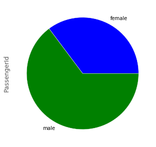

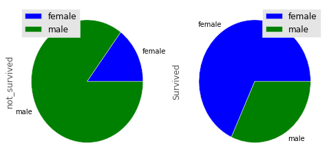

```python
#plot some stats
#i am choosing Pie graphs because i feel like they convey a classifiable metric breakdown within a sample population best

#first group data by feild of intrest
titanic_data_grouped_by_sex = titanic_data_df.groupby('Sex')

#get initial sample breakdown visualization
titanic_data_grouped_by_sex.count()['PassengerId'].plot.pie(figsize=(5, 5))

#then extract survior data and include this in a visualization
survivor_data_by_sex = extract_survival_and_non_counts(titanic_data_grouped_by_sex)
print survivor_data_by_sex
print

#plot the ratios of suvived vs not survived for each gender
survivor_data_by_sex.plot.pie(subplots=True, figsize=(8, 4))

#calc and print survival ratios
print calc_ratio(survivor_data_by_sex)
```

## Class Survival Analysis

```
        not_survived  Survived
Pclass
1                 80       136
2                 97        87
3                372       119
```

```
array([<matplotlib.axes._subplots.AxesSubplot object at 0x10c10ec10>,
       <matplotlib.axes._subplots.AxesSubplot object at 0x10c162a10>], dtype=object)
```

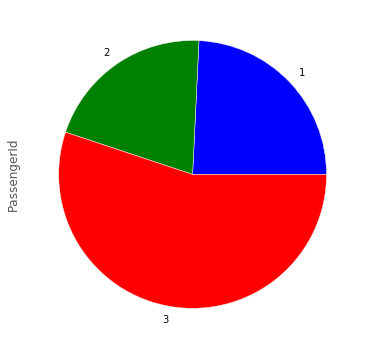

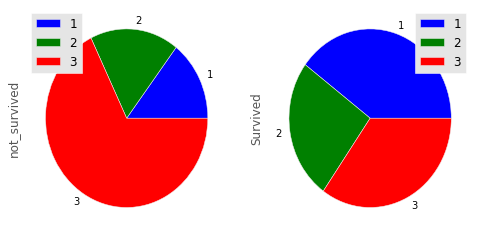

```python
#plot some stats
#i am choosing Pie graphs because i feel like they convey a classifiable metric breakdown within a sample population best

#first group data by feild of intrest
titanic_data_grouped_by_class = titanic_data_df.groupby('Pclass')

#get initial sample breakdown visualization
titanic_data_grouped_by_class.count()['PassengerId'].plot.pie(figsize=(6, 6))

#then extract survior data and include this in a visualization
survivor_data_by_class = extract_survival_and_non_counts(titanic_data_grouped_by_class)
print survivor_data_by_class

#plot the ratios of suvived vs not survived
survivor_data_by_class.plot.pie(subplots=True, figsize=(8, 4))
```

This data is a can be hard to read if not careful given that over 50% of this sample of passengers were in the 3rd class. This sould be standardized to be a survival ratio of each class, instead of survival count of each class. I will do this with a simple transpose to be able to visualize the survival rate of each class.

```
        not_survived  Survived  total  survival_ratio
Pclass
1                 80       136    216        0.629630
2                 97        87    184        0.472826
3                372       119    491        0.242363
```

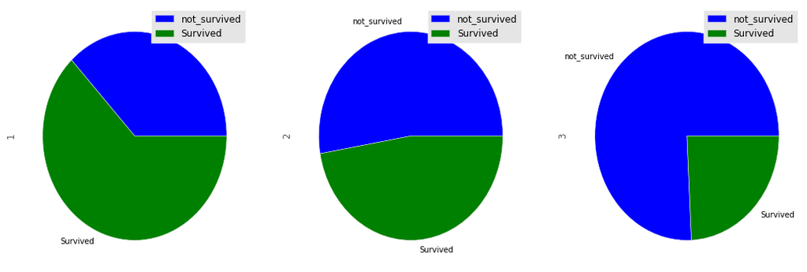

```python
survivor_data_by_class.transpose().plot.pie(subplots=True, figsize=(18, 6))

#calc and print survival ratios
print calc_ratio(survivor_data_by_class)
```

## Age Survival Analysis

```
Total records in data set 891
Number of records missing age data 177
      not_survived  Survived
Age
0.42             0         1
0.67             0         1
0.75             0         2
0.83             0         2
0.92             0         1
```

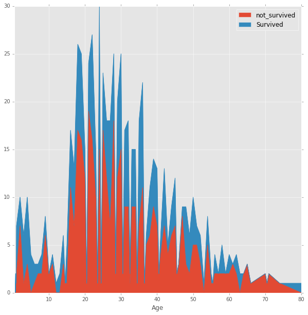

```python
#plot some stats

#quantifying limitations in the Age data
print "Total records in data set " + str(len(titanic_data_df['Age']))
print "Number of records missing age data " + str(isnan(titanic_data_df['Age']).sum())


#first group data by feild of intrest
titanic_data_grouped_by_age = titanic_data_df.groupby('Age') #group by excludes NaNs so no cleansing needed

#then extract survior data and include this in a visualization
survivor_data_by_age = extract_survival_and_non_counts(titanic_data_grouped_by_age)
print survivor_data_by_age.head()

#i choose an area line graph with stacking to show the break down of the count of each age, into survived and not survived
survivor_data_by_age.plot(kind='area', stacked=True, figsize=(10,10))
```

This gives the distribution of survivors and non survivors by age, but I am more interested if there are ages that had better survival rates. It also servse to note that 177/891 sample records will be ignored with all age calculations becuse the records do not contain any age data.

```python
#this may be a little redundant but it may be a fun use of vecorized operations
#compute the survival ratios for each data point
survivor_data_by_age['total'] = survivor_data_by_age['Survived'] + survivor_data_by_age['not_survived']
survivor_data_by_age['survival_ratio'] = survivor_data_by_age['Survived'] / survivor_data_by_age['total']

print survivor_data_by_age.head()

#survivor_data_by_age['survival_ratio'].plot() #supressed this plot as per reviewer
survivor_data_by_age['survival_ratio'].describe()
```

```
      not_survived  Survived  total  survival_ratio
Age
0.42             0         1      1               1
0.67             0         1      1               1
0.75             0         2      2               1
0.83             0         2      2               1
0.92             0         1      1               1
```

```
count    88.000000
mean      0.392889
std       0.322385
min       0.000000
25%       0.000000
50%       0.387500
75%       0.500000
max       1.000000
Name: survival_ratio, dtype: float64
```

```
[  0.42   0.67   0.75   0.83   0.92   1.     2.     3.     4.     5.     6.
   7.     8.     9.    10.    11.    12.    13.    14.    14.5   15.    16.
  17.    18.    19.    20.    20.5   21.    22.    23.    23.5   24.    24.5
  25.    26.    27.    28.    28.5   29.    30.    30.5   31.    32.    32.5
  33.    34.    34.5   35.    36.    36.5   37.    38.    39.    40.    40.5
  41.    42.    43.    44.    45.    45.5   46.    47.    48.    49.    50.
  51.    52.    53.    54.    55.    55.5   56.    57.    58.    59.    60.
  61.    62.    63.    64.    65.    66.    70.    70.5   71.    74.    80.  ]
[ 1.          1.          1.          1.          1.          0.71428571
  0.3         0.83333333  0.7         1.          0.66666667  0.33333333
  0.5         0.25        0.          0.25        1.          1.          0.5
  0.          0.8         0.35294118  0.46153846  0.34615385  0.36        0.2
  0.          0.20833333  0.40740741  0.33333333  0.          0.5         0.
  0.26086957  0.33333333  0.61111111  0.28        0.          0.4         0.4
  0.          0.47058824  0.5         0.5         0.4         0.4         0.
  0.61111111  0.5         0.          0.16666667  0.45454545  0.35714286
  0.46153846  0.          0.33333333  0.46153846  0.2         0.33333333
  0.41666667  0.          0.          0.11111111  0.66666667  0.66666667
  0.5         0.28571429  0.5         1.          0.375       0.5         0.
  0.5         0.          0.6         0.          0.5         0.          0.5
  1.          0.          0.          0.          0.          0.          0.
  0.          1.        ]
```

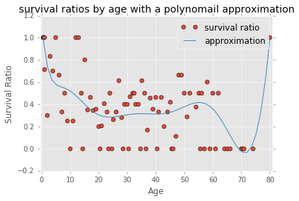

```python
#i wanted to visualize a polynomial approximation curved so the following code was taken and adapted from stack overflow
#http://stackoverflow.com/questions/19165259/python-numpy-scipy-curve-fitting

# get x and y vectors
x = survivor_data_by_age.index.values
print x
y = survivor_data_by_age['survival_ratio'].values
print y

# calculate polynomial
z = np.polyfit(x, y, 10) #i experimented with the order of the polynomial to achive more detail, without being unessisary
f = np.poly1d(z)

# calculate new x's and y's
x_new = np.linspace(x[0], x[-1], 50)
y_new = f(x_new)

plt.plot(x,y,'o', x_new, y_new)
plt.xlim([x[0]-1, x[-1] + 1 ])
plt.xlabel('Age')
plt.ylabel('Survival Ratio')
plt.title('survival ratios by age with a polynomail approximation')
plt.legend(['survival ratio', 'approximation'])
plt.show()
```

Now its much clearer that survival ratio was much higher for the very young, then declining to a slight plateau around the sample's average. This leads to an interesting dip and then sharp spike towards the very old.